# Particionando a diversidade beta

Gabriel F. B. Rodrigues

03 de julho de 2020

Há muito tempo naturalistas e ecólogos entendem que a diversidade biológica não está homogeneamente distribuída na superfície da Terra. Dessa forma, a diversidade beta tenta entender o quão diferente (ou quão similar) é a comunidade de dois ou mais locais (ou tempos) distintos. Geralmente as métricas de diversidade beta baseada em similaridade variam de zero (comunidades totalmente distintas) até um (comunidades totalmente similares).

## O que torna duas comunidades distintas

Potencialmente dois processos distintos e complementares podem resultar na diferença das comunidades (Baselga and Orme 2012).

1. **Reposição de espécies (turnover)**: Consiste na substituição de espécies de um local por espécies diferentes em outro local.
2. **Perda (ou ganho) de espécies**: Consiste no desaparecimento (ou aparecimento) de uma espécie em um único local, tornando assim a comunidade de menor número de espécies (menor riqueza) um subconjunto da comunidade com maior número de espécies. Esse padrão pode ser chamado de aninhamento **(nestedness)**.

### Funções do pacote betapart () (Baselga and Orme 2012)

A função desse pacote é disponibilizar um conjunto de ferramentas para calcular e particionar a diversidade beta em seus dois componentes descritos **(turnover e nestedness)**

## Calculando os componentes e database utilizado.

Para calcular os componentes da diversidade beta iremos utilizar a Database embutida no pacote ‘betapart()’ que consiste na diversidade de aves dos Estados Unidos da América nos anos de 1980 e 2000.

```r
require(betapart) #carregar pacote
data(bbsData) #Carregar database
```

### Objetos utilizados

Primeiramente é necessário criar uma matriz de dissimilaridade **(betapart object)** baseado numa matriz de presença/ausência, necessário para outras análises utilizando a função `betapart.core()`. O conjunto de dados aceito para todas as funções do `betapart()` consiste em uma matrix (m) de presença (1) e ausência (0) de *m* espécies (colunas) em *n* locais (linhas).

```r
#Criar objeto betapart
beta1980<- betapart.core(bbs1980) #Criando objeto da comunidade de Aves de 1980
beta2000<- betapart.core(bbs2000) #Criando objeto da comunidade de Aves de 2000
```

Agora com os objetos criados é possível calcular a diversidade beta total e seus 2 componentes (turnover e nestedness).

```r
bm1980<-beta.multi(beta1980, "sorensen")
bm2000<-beta.multi(beta2000,"sorensen")
```

### Função `beta.pair()`

Para calcular a diversidade beta total e seus componentes entre cada par de local amostrado utiliza-se a função `beta.pair()`.

```r
bp1980<-beta.pair(beta1980, "sorensen")
bp2000<-beta.pair(beta2000,"sorensen")
```

Para representar graficamente a diversidade beta pode ser feito uma análise de agrupamento (clusters) com os dados já calculados.

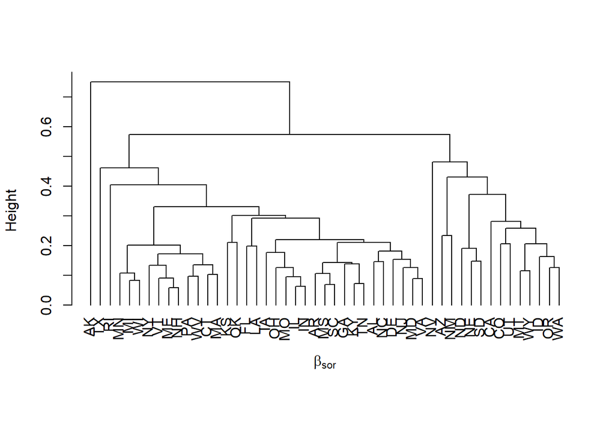

```r
plot(hclust(bp1980$beta.sor, method="average"), hang=-1, main='', sub='', xlab='')
title(xlab=expression(beta[sor]), line=0.3)
```

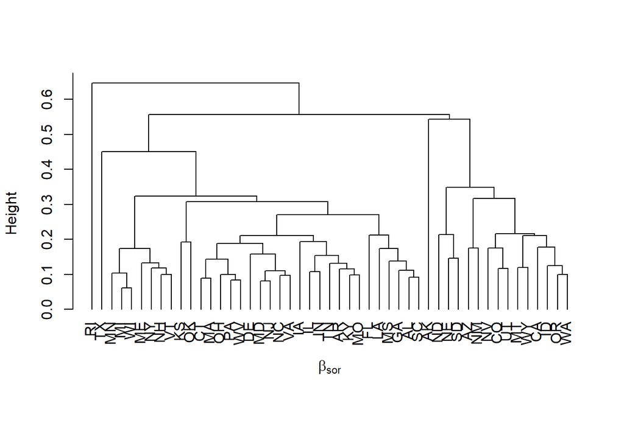

```r
plot(hclust(bp2000$beta.sor, method="average"), hang=-1, main='', sub='', xlab='')
title(xlab=expression(beta[sor]), line=0.3)
```

```r
require(tidyverse)
#Acessando componentes
turnover<- as.matrix(bp1980$beta.sim) ##Para acessar o componente turnover
nestedness<- as.matrix(bp1980$beta.sne)##Para acessar o componente nestedness

#Manipulando os dados
library(reshape)
turnover<-melt(turnover)
nestedness<-melt(nestedness)

turnover<- data.frame(turnover, component = "turnover")
nestedness<- data.frame(nestedness, component = "nestedness")
df1<- bind_rows(turnover, nestedness)
```

Para representar os valores dos componentes encontrados utilizaremos um gráfico de densidade utilizando o pacote `ggplot2()`

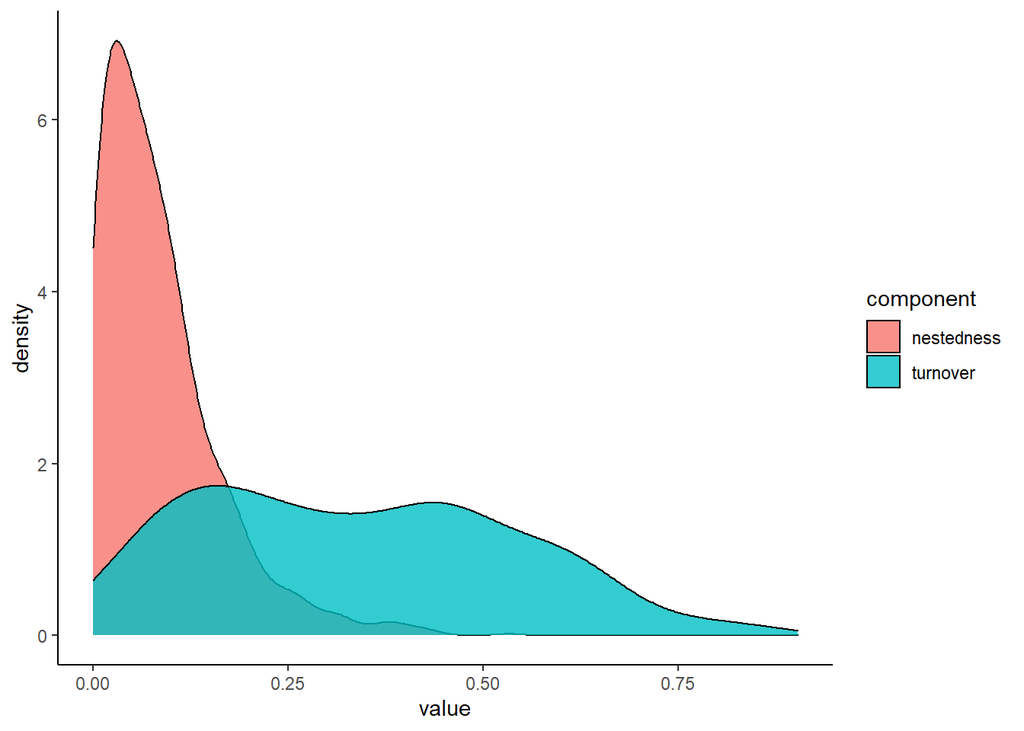

```r
ggplot(data=df1, aes(group = component,fill=component, x = value)) +
  geom_density(adjust=1.5, alpha = .8)+ theme_classic() + labs()
```

Podemos perceber que o componente **nestedness** possuem geralmente menores valores (0 - 0.25), dessa forma a distinção dessas comunidades é explicada principalmente pelo componente **turnover**, ou seja, pela reposição (substituição) de espécies entre um local e outro.

Qualquer dúvida, correção ou sugestão pode ser encaminhada para gfellipe5@gmail.com

### Referências

Baselga, Andrés, and C David L Orme. 2012. “Betapart: An R Package for the Study of Beta Diversity.” *Methods in Ecology and Evolution* 3 (5). Wiley Online Library: 808–12.